# OC_IA_P8_KERAS_RESNET50_NO_augmentation

CELLS SPECIFIC TO GOOGLE COLAB USE

```python
%pip install silence_tensorflow albumentations pyyaml h5py
```

```
     |████████████████████████████████| 631 kB 3.7 MB/s
  Attempting uninstall: imgaug
    Found existing installation: imgaug 0.2.9
    Uninstalling imgaug-0.2.9:
      Successfully uninstalled imgaug-0.2.9
```

```python
import shutil
import sys
from google.colab import drive
import sys

drive.mount('/content/drive')
drive_dir = '/content/drive/MyDrive/OPENCLASSROOMS/P8/'
sys.path.insert(0,drive_dir)
```

# OC-IA-P8 KERAS RESNET50

Sources :

- **Tutorials**  
  https://www.youtube.com/watch?v=wYiJHFQ6f0Q&ab_channel=IdiotDeveloper  
  https://medium.com/@kenneth.ca95/a-guide-to-transfer-learning-with-keras-using-resnet50-a81a4a28084b  
  http://ronny.rest/tutorials/module/seg_01/segmentation_08_tensorflow/
- **Model implementation**  
  https://discuss.tensorflow.org/t/proper-use-of-keras-imagedatagenerator-create-masks-for-segmentation-and-sample-weight-parameter/3134/3 (why ImageDataGenerator is not recommended here)  
  https://fse.studenttheses.ub.rug.nl/18139/1/AI_BA_2018_FlorisvanBeers.pdf (use of MeanIoU as a loss function)

```python
augmentation = False
```

```python
from silence_tensorflow import silence_tensorflow
silence_tensorflow()
import tensorflow as tf
from tensorflow.keras.layers import Conv2D, BatchNormalization, Activation, MaxPool2D, Conv2DTranspose, Concatenate, Input
from tensorflow.keras.models import Model
from tensorflow.keras.applications.resnet import preprocess_input, ResNet50
from tensorflow.keras.losses import CategoricalCrossentropy
from tensorflow.keras.optimizers import Adam
from tensorflow.keras.metrics import OneHotMeanIoU, MeanIoU
from PIL import Image
import matplotlib.pyplot as plt
import glob
import os
import shutil
import datetime
import itertools
import albumentations as A
import numpy as np
from sklearn.model_selection import train_test_split
import random

from utils import colorize
```

```python
NB_CLASSES = 8
IMG_HEIGHT = 1024
IMG_WIDTH = 2048

batch_size = 8
image_size = (224,224)
input_shape = (224,224,3)
```

```python
adam_initial_lr = 1e-2
epochs = 50
steps_per_epoch = 50
validation_steps = 50
```

https://keras.io/api/applications/ :

> if you have set image_data_format=channels_last, then any model loaded from this repository will get built according to the TensorFlow data format convention, "Height-Width-Depth".

This is the case in our config.

# Data preprocessing

The input images fed into the model must be of size (224, 224) and the model will return a same-sized mask. So to train our model, we must resize and preprocess our training data (real images and labeled images).

```python
validation_frac = 0.1
test_frac = 0.1

# get images and masks dirs
imgs_dir = drive_dir + 'Cityscapes/train/true_imgs/imgs/'
masks_dir = drive_dir + 'Cityscapes/train/labeled_imgs/imgs/'



# define train set and validation set (of images names)
img_names = os.listdir(imgs_dir)
train_names, val_names = train_test_split(img_names,
                                        random_state=42,
                                        test_size=(validation_frac))

# define test set
test_imgs_dir = drive_dir + 'Cityscapes/test/true_imgs/imgs/'
test_masks_dir = drive_dir + 'Cityscapes/test/labeled_imgs/imgs/'
test_names = os.listdir(test_imgs_dir)
```

We add a transformation function that randomly transforms the image (and the corresponding mask) by:

- cropping
- horizontal flip
- rotation +/- 15°
- modifying brightness and contrast
- add motion blur,  
  with a probability of 0.5.

```python
class ImageTransformer():
    def __init__(self):
        self._transform = A.Compose([
            A.RandomSizedCrop(min_max_height=(244, 1024), width=512, height=512, p=0.5),
            A.HorizontalFlip(p=0.5),
            A.Rotate(limit=15, p=0.5),
            A.RandomBrightnessContrast(p=0.5),
            A.MotionBlur(p=0.5)
        ])

    def transform_image_and_mask(self, img, mask):
        '''
        Return transformed img and mask after random transformation
        (see self.transform : crop, horizontal fil, brightness, contrast.)
        '''
        transformed = self._transform(image=img, mask=mask)
        return transformed['image'], transformed['mask']
```

Examples of transformations :

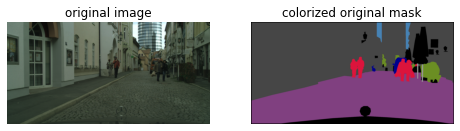

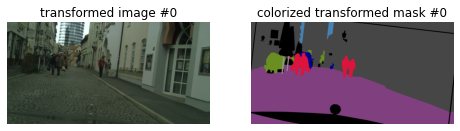

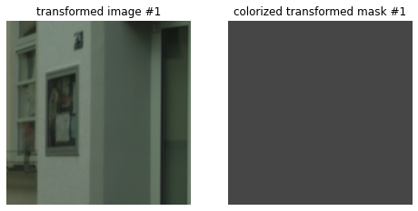

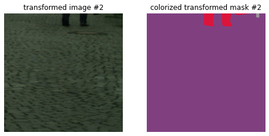

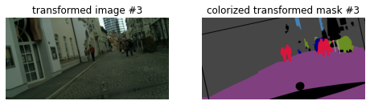

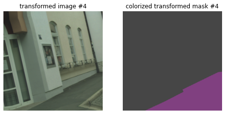

```python
it = ImageTransformer()

# get original image and its mask

img_name = imgs_dir + train_names[0]
img = tf.io.read_file(img_name)
img = tf.io.decode_png(img)
img = img.numpy()

mask_name = masks_dir + train_names[0]
mask = tf.io.read_file(mask_name)
mask = tf.io.decode_png(mask)
mask = mask.numpy()
colored_mask = colorize(mask)

# plot original image and colorized mask
fig, axs = plt.subplots(1,2, figsize=(8,8))
axs[0].imshow(img)
axs[0].title.set_text('original image')
axs[0].axis('off')

axs[1].imshow(colored_mask)
axs[1].title.set_text('colorized original mask')
axs[1].axis('off')
plt.show()

# plot 5 random transformations of image and mask
for i in range(5):
    transformed_img, transformed_mask = it.transform_image_and_mask(img, mask)
    colored_mask = colorize(transformed_mask)
    fig, axs = plt.subplots(1,2, figsize=(8,8))
    axs[0].imshow(transformed_img)
    axs[0].title.set_text(f'transformed image #{i}')
    axs[0].axis('off')

    axs[1].imshow(colored_mask)
    axs[1].title.set_text(f'colorized transformed mask #{i}')
    axs[1].axis('off')
    plt.show()
```

We also create a data generator that will yield batches of images and their corresponding masks, randomly transformed.

```python
class BatchedDataGenerator():
    """
    Yield preprocessed images and masks ready to feed the model.
    Parameters:

    - batch_size: as its name suggests
    - image_size: requested size to feed the model
    - imgs_names: list of images names (names must be the same in imgs dir and masks dir)
    - imgs_dir, masks_dirs: where to find corresponding images with imgs names.
    """
    def __init__(self, batch_size, image_size, imgs_names, imgs_dir, masks_dir):
        self.batch_size = batch_size
        self.image_size = image_size
        self.imgs_names = imgs_names
        self.imgs_dir = imgs_dir
        self.masks_dir = masks_dir
        self.transform = ImageTransformer().transform_image_and_mask
        self.preprocess_input = preprocess_input

    def augmented_and_processed_img_and_mask_for(self, name, augment=True):
        """
        Return a tuple of Tensors (preprocessed image, preprocessed mask)
        for image and mask named <name> (found respectively in self.imgs_dir
        and self.masks_dir).
        If augment = True, image and mask are randomly augmented
        (crop, horizontal flip, brightness, contrast), else they are left unchanged,
        then :
        - image is preprocessed as required by ResNet50 model
        - each class pixel in mask is one-hot-encoded
        Eventually, image and mask are resized to the input size required
        by ResNet50 input layer.
        """
        img_name = self.imgs_dir + name
        mask_name = self.masks_dir + name

        img = tf.io.read_file(img_name)
        img = tf.io.decode_png(img)
        img = img.numpy()

        mask = tf.io.read_file(mask_name)
        mask = tf.io.decode_png(mask)
        mask = mask.numpy()

        # Optionally apply augmentation to img and mask
        transformed_img, transformed_mask = img, mask
        if augment:
            transformed_img, transformed_mask = self.transform(img, mask)

        # Preprocess according to model requirements
        preprocessed_img = self.preprocess_input(transformed_img)
        ohe_mask = tf.squeeze(tf.one_hot(transformed_mask, depth=NB_CLASSES))

        # Resize image and mask
        resized_img = tf.image.resize(preprocessed_img, image_size)
        resized_mask = tf.image.resize(ohe_mask, image_size)

        return resized_img, resized_mask

    def batch_generator(self, augment):
        '''
        Infinite generator.
        Return tuple of tensors ([self.batch_size, img_witdh, img_height, ...]) of
        augmented and preprocessed images and masks based on self.imgs_names list.
        '''
        while True:
            shuffled_list = self.imgs_names.copy()
            random.shuffle(shuffled_list)

            for i in range(0, len(shuffled_list) - batch_size, batch_size):
                names_batch = shuffled_list[i: i+ batch_size]
                imgs = []
                masks = []
                for name in names_batch:
                    img, mask = self.augmented_and_processed_img_and_mask_for(name, augment)
                    imgs.append(img)
                    masks.append(mask)
                imgs = tf.convert_to_tensor(imgs)
                masks = tf.convert_to_tensor(masks)
                yield (imgs, masks)
```

Thaks to this class we create the generators we need to train and validate results of the model. Validation and test data will not be augmented.

```python
train_data_generator = BatchedDataGenerator(batch_size=batch_size,
                           image_size=image_size,
                           imgs_names=train_names,
                           imgs_dir=imgs_dir,
                           masks_dir=masks_dir).batch_generator(augment=augmentation)

val_data_generator = BatchedDataGenerator(batch_size=batch_size,
                           image_size=image_size,
                           imgs_names=val_names,
                           imgs_dir=imgs_dir,
                           masks_dir=masks_dir).batch_generator(augment=False)

test_data_generator = BatchedDataGenerator(batch_size=batch_size,
                           image_size=image_size,
                           imgs_names=test_names,
                           imgs_dir=test_imgs_dir,
                           masks_dir=test_masks_dir).batch_generator(augment=False)
```

# Create custom model from ResNet50

This model is trained on image classification, so we cannot use it directly for semantic segmentation. But we can reuse its convolutional layers to build a Unet model and perform image segmentation.

We build a Unet model where the output of each convolutional layer is concatenated to that of the corresponding decoder (Convolutional transpose) layer.

```python
def conv_block(input_, num_filters):
    x = Conv2D(num_filters, 3, padding="same")(input_)
    x = BatchNormalization()(x)
    x = Activation("relu")(x)

    x = Conv2D(num_filters, 3, padding="same")(x)
    x = BatchNormalization()(x)
    x = Activation("relu")(x)

    return x

def decoder_block(input_, skip_features, num_filters):
    x = Conv2DTranspose(num_filters, (2, 2), strides=2, padding="same")(input_)
    x = Concatenate()([x, skip_features])
    x = conv_block(x, num_filters)
    return x

def build_resnet50_unet(input_shape, num_classes, adam_initial_lr=1e-1):
    inputs = Input(input_shape)
    resnet50 = ResNet50(include_top=False, weights="imagenet", input_tensor=inputs)
    resnet50.trainable = False

    # Encoder
    s1 = resnet50.get_layer(index=0).output
    s2 = resnet50.get_layer("conv1_relu").output
    s3 = resnet50.get_layer("conv2_block3_out").output
    s4 = resnet50.get_layer("conv3_block4_out").output

    # Bridge
    b1 = resnet50.get_layer("conv4_block6_out").output

    # Decoder
    d1 = decoder_block(b1, s4, 512)
    d2 = decoder_block(d1, s3, 256)
    d3 = decoder_block(d2, s2, 128)
    d4 = decoder_block(d3, s1, 64)

    # Output
    outputs = Conv2D(num_classes, (1, 1),  padding="same",
                     activation='softmax')(d4)

    # Instantiation
    model = Model(inputs, outputs, name="ResNet50_U-Net")

    # Compilation
    lr_schedule = tf.keras.optimizers.schedules.ExponentialDecay(
    initial_learning_rate=adam_initial_lr,
    decay_steps=10000,
    decay_rate=0.9)

    optimizer = tf.keras.optimizers.Adam(learning_rate=lr_schedule)
    model.compile(loss=CategoricalCrossentropy(),
                 optimizer=optimizer,
                 metrics = ['accuracy', OneHotMeanIoU(NB_CLASSES)],
                )
    return model
```

# Build and train model

```python
experiment_path = f"AUGMENTATION_{augmentation}_adam_lr_{adam_initial_lr}_-_steps_per_epoch_{steps_per_epoch}_-_val_steps_{validation_steps}_batch_size_{batch_size}"
checkpoint_path = drive_dir + experiment_path + "cp.ckpt"
history_path = drive_dir + experiment_path + 'history.csv'
history_logger = tf.keras.callbacks.CSVLogger(history_path, separator=",")

if not os.path.isdir(drive_dir + experiment_path):
  print('Instantiating new model...')
  os.mkdir(drive_dir + experiment_path)
  model = build_resnet50_unet(input_shape, NB_CLASSES, adam_initial_lr=adam_initial_lr)
else:
  print('Fetching recorded model...')
  model = tf.keras.models.load_model(checkpoint_path)
print('Done.')
```

```
Instantiating new model...
Downloading data from https://storage.googleapis.com/tensorflow/keras-applications/resnet/resnet50_weights_tf_dim_ordering_tf_kernels_notop.h5
Done.
```

```python
cp_callback = tf.keras.callbacks.ModelCheckpoint(filepath=checkpoint_path,
                                                 save_weights_only=False,
                                                  monitor='val_one_hot_mean_io_u',
                                                  mode='max',
                                                  save_best_only=True,
                                                 verbose=1)
```

```python
history = model.fit(train_data_generator,
                    batch_size=batch_size,
                    epochs=epochs,
                    verbose=1,
                    steps_per_epoch=steps_per_epoch,
                    validation_data=val_data_generator,
                    validation_steps=validation_steps,
                    callbacks=[history_logger, cp_callback])
```

```
Epoch 1: val_one_hot_mean_io_u improved from -inf to 0.20075, saving model to /content/drive/MyDrive/OPENCLASSROOMS/P8/AUGMENTATION_False_adam_lr_0.01_-_steps_per_epoch_50_-_val_steps_50_batch_size_8cp.ckpt
Epoch 2: val_one_hot_mean_io_u improved from 0.20075 to 0.35532, saving model to /content/drive/MyDrive/OPENCLASSROOMS/P8/AUGMENTATION_False_adam_lr_0.01_-_steps_per_epoch_50_-_val_steps_50_batch_size_8cp.ckpt
Epoch 3: val_one_hot_mean_io_u improved from 0.35532 to 0.37049, saving model to /content/drive/MyDrive/OPENCLASSROOMS/P8/AUGMENTATION_False_adam_lr_0.01_-_steps_per_epoch_50_-_val_steps_50_batch_size_8cp.ckpt
Epoch 4: val_one_hot_mean_io_u improved from 0.37049 to 0.42346, saving model to /content/drive/MyDrive/OPENCLASSROOMS/P8/AUGMENTATION_False_adam_lr_0.01_-_steps_per_epoch_50_-_val_steps_50_batch_size_8cp.ckpt
Epoch 5: val_one_hot_mean_io_u improved from 0.42346 to 0.46911, saving model to /content/drive/MyDrive/OPENCLASSROOMS/P8/AUGMENTATION_False_adam_lr_0.01_-_steps_per_epoch_50_-_val_steps_50_batch_size_8cp.ckpt
Epoch 6: val_one_hot_mean_io_u improved from 0.46911 to 0.50205, saving model to /content/drive/MyDrive/OPENCLASSROOMS/P8/AUGMENTATION_False_adam_lr_0.01_-_steps_per_epoch_50_-_val_steps_50_batch_size_8cp.ckpt
Epoch 7: val_one_hot_mean_io_u improved from 0.50205 to 0.54988, saving model to /content/drive/MyDrive/OPENCLASSROOMS/P8/AUGMENTATION_False_adam_lr_0.01_-_steps_per_epoch_50_-_val_steps_50_batch_size_8cp.ckpt
Epoch 8: val_one_hot_mean_io_u improved from 0.54988 to 0.56833, saving model to /content/drive/MyDrive/OPENCLASSROOMS/P8/AUGMENTATION_False_adam_lr_0.01_-_steps_per_epoch_50_-_val_steps_50_batch_size_8cp.ckpt
Epoch 9: val_one_hot_mean_io_u did not improve from 0.56833
Epoch 10: val_one_hot_mean_io_u did not improve from 0.56833
Epoch 11: val_one_hot_mean_io_u did not improve from 0.56833
Epoch 12: val_one_hot_mean_io_u did not improve from 0.56833
Epoch 13: val_one_hot_mean_io_u improved from 0.56833 to 0.59148, saving model to /content/drive/MyDrive/OPENCLASSROOMS/P8/AUGMENTATION_False_adam_lr_0.01_-_steps_per_epoch_50_-_val_steps_50_batch_size_8cp.ckpt
Epoch 14: val_one_hot_mean_io_u did not improve from 0.59148
Epoch 15: val_one_hot_mean_io_u improved from 0.59148 to 0.60805, saving model to /content/drive/MyDrive/OPENCLASSROOMS/P8/AUGMENTATION_False_adam_lr_0.01_-_steps_per_epoch_50_-_val_steps_50_batch_size_8cp.ckpt
Epoch 16: val_one_hot_mean_io_u did not improve from 0.60805
Epoch 17: val_one_hot_mean_io_u improved from 0.60805 to 0.61631, saving model to /content/drive/MyDrive/OPENCLASSROOMS/P8/AUGMENTATION_False_adam_lr_0.01_-_steps_per_epoch_50_-_val_steps_50_batch_size_8cp.ckpt
Epoch 18: val_one_hot_mean_io_u did not improve from 0.61631
Epoch 19: val_one_hot_mean_io_u did not improve from 0.61631
Epoch 20: val_one_hot_mean_io_u did not improve from 0.61631
Epoch 21: val_one_hot_mean_io_u did not improve from 0.61631
Epoch 22: val_one_hot_mean_io_u improved from 0.61631 to 0.64005, saving model to /content/drive/MyDrive/OPENCLASSROOMS/P8/AUGMENTATION_False_adam_lr_0.01_-_steps_per_epoch_50_-_val_steps_50_batch_size_8cp.ckpt
Epoch 23: val_one_hot_mean_io_u did not improve from 0.64005
Epoch 24: val_one_hot_mean_io_u did not improve from 0.64005
Epoch 25: val_one_hot_mean_io_u did not improve from 0.64005
Epoch 26: val_one_hot_mean_io_u did not improve from 0.64005
Epoch 27: val_one_hot_mean_io_u improved from 0.64005 to 0.65331, saving model to /content/drive/MyDrive/OPENCLASSROOMS/P8/AUGMENTATION_False_adam_lr_0.01_-_steps_per_epoch_50_-_val_steps_50_batch_size_8cp.ckpt
Epoch 28: val_one_hot_mean_io_u did not improve from 0.65331
Epoch 29: val_one_hot_mean_io_u did not improve from 0.65331
Epoch 30: val_one_hot_mean_io_u did not improve from 0.65331
Epoch 31: val_one_hot_mean_io_u improved from 0.65331 to 0.65940, saving model to /content/drive/MyDrive/OPENCLASSROOMS/P8/AUGMENTATION_False_adam_lr_0.01_-_steps_per_epoch_50_-_val_steps_50_batch_size_8cp.ckpt
Epoch 32: val_one_hot_mean_io_u did not improve from 0.65940
Epoch 33: val_one_hot_mean_io_u did not improve from 0.65940
Epoch 34: val_one_hot_mean_io_u did not improve from 0.65940
Epoch 35: val_one_hot_mean_io_u did not improve from 0.65940
Epoch 36: val_one_hot_mean_io_u improved from 0.65940 to 0.66017, saving model to /content/drive/MyDrive/OPENCLASSROOMS/P8/AUGMENTATION_False_adam_lr_0.01_-_steps_per_epoch_50_-_val_steps_50_batch_size_8cp.ckpt
Epoch 37: val_one_hot_mean_io_u did not improve from 0.66017
Epoch 38: val_one_hot_mean_io_u improved from 0.66017 to 0.67649, saving model to /content/drive/MyDrive/OPENCLASSROOMS/P8/AUGMENTATION_False_adam_lr_0.01_-_steps_per_epoch_50_-_val_steps_50_batch_size_8cp.ckpt
Epoch 39: val_one_hot_mean_io_u did not improve from 0.67649
Epoch 40: val_one_hot_mean_io_u did not improve from 0.67649
Epoch 41: val_one_hot_mean_io_u did not improve from 0.67649
Epoch 42: val_one_hot_mean_io_u did not improve from 0.67649
Epoch 43: val_one_hot_mean_io_u did not improve from 0.67649
Epoch 44: val_one_hot_mean_io_u did not improve from 0.67649
Epoch 45: val_one_hot_mean_io_u improved from 0.67649 to 0.68105, saving model to /content/drive/MyDrive/OPENCLASSROOMS/P8/AUGMENTATION_False_adam_lr_0.01_-_steps_per_epoch_50_-_val_steps_50_batch_size_8cp.ckpt
Epoch 46: val_one_hot_mean_io_u did not improve from 0.68105
Epoch 47: val_one_hot_mean_io_u improved from 0.68105 to 0.68289, saving model to /content/drive/MyDrive/OPENCLASSROOMS/P8/AUGMENTATION_False_adam_lr_0.01_-_steps_per_epoch_50_-_val_steps_50_batch_size_8cp.ckpt
Epoch 48: val_one_hot_mean_io_u did not improve from 0.68289
Epoch 49: val_one_hot_mean_io_u did not improve from 0.68289
Epoch 50: val_one_hot_mean_io_u did not improve from 0.68289
```

```python
model.save_weights(f'{drive_dir}/weights/Augmentation_{augmentation}/weights')
```

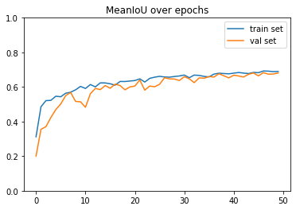

```python
plt.plot(history.history['one_hot_mean_io_u'], label='train set')
plt.plot(history.history['val_one_hot_mean_io_u'], label='val set')
plt.title('MeanIoU over epochs')
plt.legend()
plt.ylim([0, 1]);
```

# Evaluate the model

```python
*_, test_mean_iou = model.evaluate(test_data_generator, batch_size=batch_size, steps=validation_steps)
print('MeaIoU on generated test set:','{:.2%}'.format(test_mean_iou))
```

```
MeaIoU on generated test set: 65.91%
```

# Predict with model

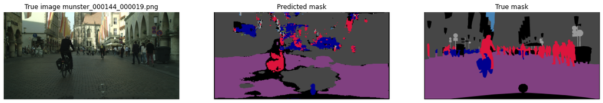

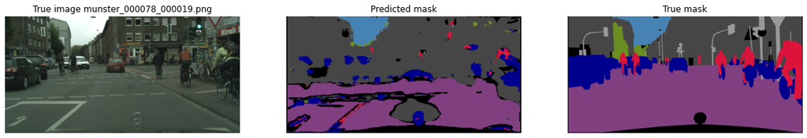

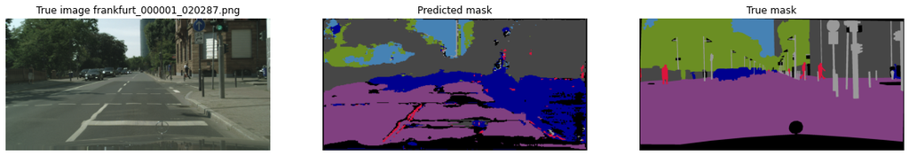

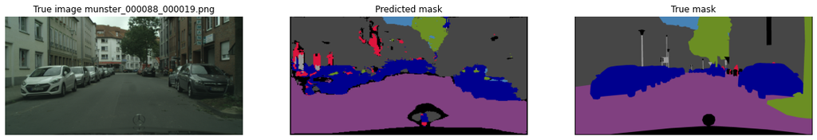

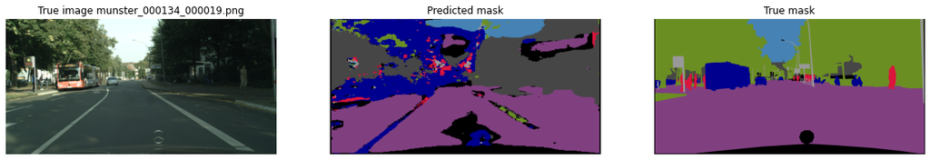

```python
def png_as_ndarray(img_path):
  '''Return png image as numpy ndarray.'''
  img = tf.io.read_file(img_path)
  img = tf.io.decode_png(img)
  img = img.numpy()
  return img

true_imgs_dir = drive_dir + 'Cityscapes/test/true_imgs/imgs/'
masks_dir = drive_dir + 'Cityscapes/test/labeled_imgs/imgs/'
samples_names = random.choices(test_names, k=5)

for img_name in samples_names:
  true_img = png_as_ndarray(true_imgs_dir + img_name)
  true_mask = png_as_ndarray(masks_dir + img_name)
  true_colored_mask = colorize(true_mask)


  # predict probabilities with model
  preprocessed_img = preprocess_input(true_img)
  preprocessed_img = tf.image.resize(preprocessed_img, image_size)
  preprocessed_img = tf.cast(preprocessed_img, tf.uint8)
  preprocessed_img = tf.expand_dims(preprocessed_img,0)
  predicted_prob = model.predict(preprocessed_img)[0]

  # select class with highest probability
  predicted_mask = tf.keras.backend.argmax(predicted_prob, axis=-1)
  predicted_colored_mask = colorize(predicted_mask.numpy().reshape((*image_size,1)))

  # resize image
  predicted_colored_mask = tf.image.resize(predicted_colored_mask,
                                           (1024, 2048), method='nearest')

  # plot original, predicted and labeled images

  fig, axs = plt.subplots(1,3, figsize=(20,12))
  axs[0].imshow(true_img)
  axs[0].title.set_text('True image ' + img_name)
  axs[0].axis('off')
  axs[1].imshow(predicted_colored_mask)
  axs[1].title.set_text(f'Predicted mask')
  axs[1].axis('off');
  axs[2].imshow(true_colored_mask)
  axs[2].title.set_text('True mask')
  axs[2].axis('off')
  plt.show();
```